# train

Dr. Wayne Stewart

2025-03-05

# Introduction

So far in the course we have shown you how to **USE** the dpq and r functions. In this problem you will need to create them for a particular random variable associated with a train being late to a station.

[figure not shown]

# Tasks

## Task 1

Using the above density find “c”. You should use $\int_{-\infty}^{\infty}f(t)dt = 1$

```r
# proof
myg <- function(x) {
  1/500*(25 - x^2)
}
l <- integrate(myg, -5, 5)
c = 1/l$value
c
```

```
## [1] 3
```

## Task 2

- In R create the density function `dtrain(x).`Hint: Use `ifelse()`, please note that the function must return a value for any $x\in \Re$
- Plot the density over (-10,10)
- Evaluate `dtrain(x = 0)`

```r
dtrain <- function(x) {
  ifelse( x > -5 & x < 5, 3/500*(25 - x^2), 0)
}

dtrain(x = 0)
```

```
## [1] 0.15
```

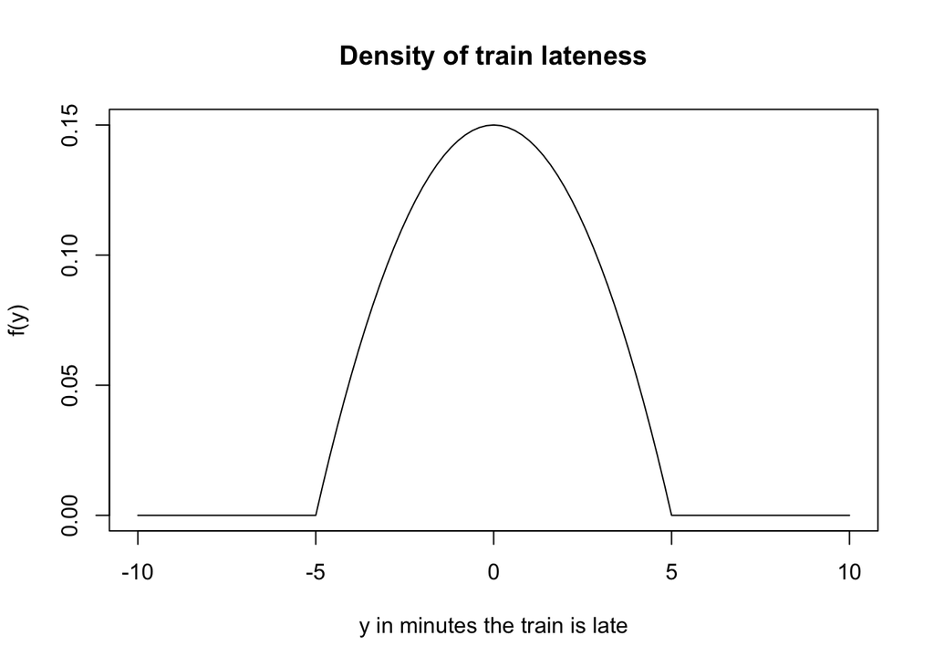

```r
curve(dtrain,
      xlim = c(-10, 10),
      xlab = "y in minutes the train is late",
      ylab = "f(y)",
      main = "Density of train lateness")
```

## Task 3

- In R create the cumulative distribution function `ptrain(q)`, please note that the function must return a value for any $q\in \Re$
- Plot the cumulative distribution function over (-10,10)
- Evaluate `ptrain(q = 0)`

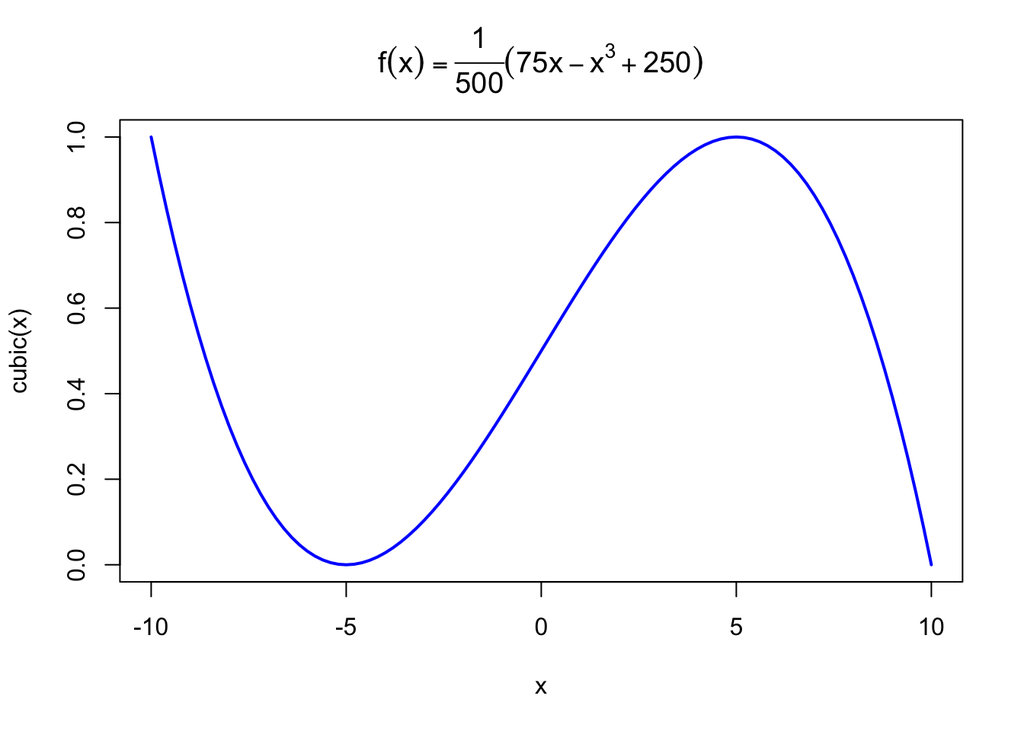

```r
ptrain <- function(q){
  ifelse(q <= -5,
         0,
         ifelse(q > -5 & q < 5,
                1/500*(75*q - q^3 + 250),
                1))
}


cubic <- function(x) {
  1/500 * (75*x - x^3 + 250)
}

curve(cubic(x),
      xlim=c(-10,10),
      lwd = 2,
      col="blue",
      main = bquote(f(x) == frac(1, 500) * (75*x - x^3 + 250)))
```

```r
ptrain(0)
```

```
## [1] 0.5
```

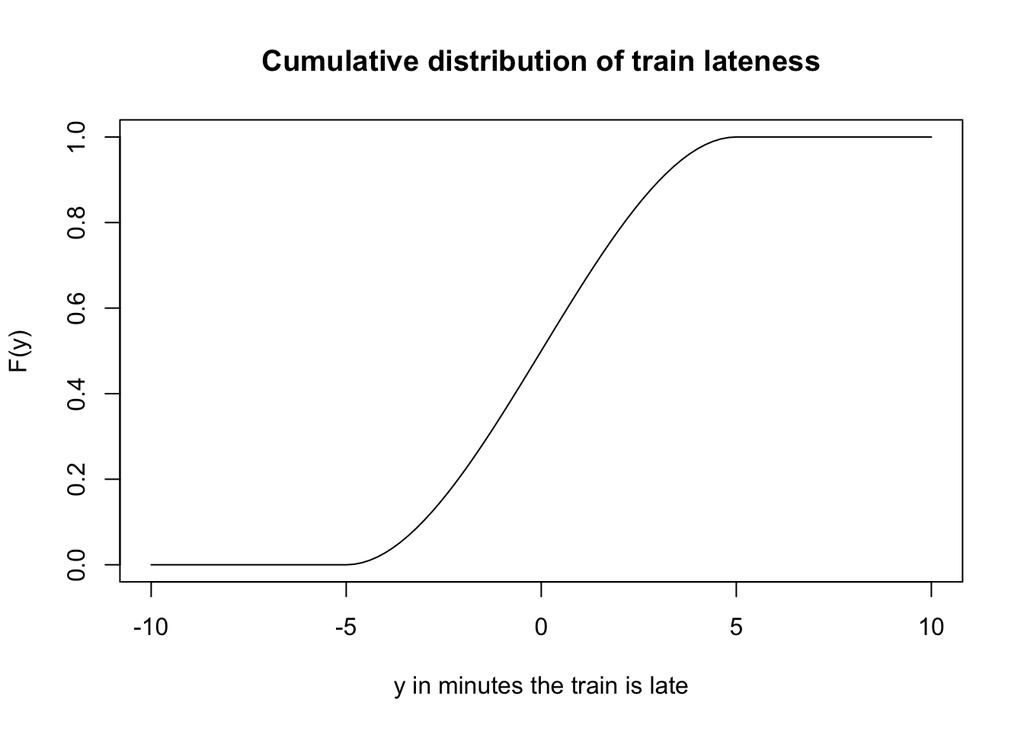

```r
curve(ptrain,
      xlim=c(-10, 10),
      xlab = "y in minutes the train is late",
      ylab = "F(y)",
      main = "Cumulative distribution of train lateness")
```

## Task 4

- In R create the quantile function `qtrain(p)`, you will need to use the w-F Theorem where you set w to a vector of values (these are the components of p).

You can do this in a number of ways:

1. Use $w = F(y),\; w - F(y) = 0, \;k(y) = w - F(y)$ we want the roots of $k(y)$. You can use `stats::uniroot()`
2. Use $w = F(y),\; w - F(y) = 0, \; h(y) = | w-F(y) |$ and find $y_{min}$ such that $h(y_{min})$ is a minimum.

There will be a minimum for each w component. This minimum can be found with `optimize()`

- Evaluate `qtrain(p = 0.75)`
- Evaluate `qtrain(p = c(0.25,0.5,0.75))`

```r
library(purrr)
library(stats)

qtrain <- function(p) {
  ifelse(p < 0 | p > 1, stop("p must be between 0 and 1"), "")

  myroot <- function(p) {
    k <- function(x) {
      p - 1/500*(75*x - x^3 + 250) # p - F(x)
    }

    l <- stats::uniroot(k, interval = c(-5, 5))
    l$root
  }

  purrr::map_vec(.x = p, .f = myroot)
}

qtrain(p = 0.75)
```

```
## [1] 1.736455
```

```r
qtrain(p = c(0.25, 0.5, 0.75))
```

```
## [1] -1.736455  0.000000  1.736455
```

## Task 5

- In R create the random sample function `rtrain(n)`, you will need to use the w-F Theorem where you set w to a vector of values from the `uniform(0,1)` distribution.
- Make a random sample of size $n=10000$ and use it to make a relative frequency histogram with the train density overlain.

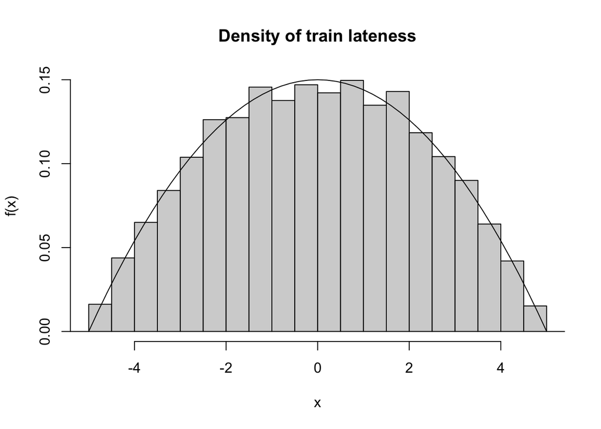

```r
rtrain <- function(n) {
  r <- runif(n)
  qtrain(r)
}

l <- rtrain(n = 10000)
h <- hist(l, plot = FALSE)
hist(l,
     freq = FALSE,
     main = "Density of train lateness",
     xlab = "x",
     ylab = "f(x)")
curve(dtrain(x),
      xlim=c(-10, 10),
      add=TRUE)
```